# 27_mixture_Models slides

### Mixture Model Intuition

- Knowing that there is a difference between the spending of male and female purchases on a platform and given the sales data where males and females are not labeled, we can use k-means to find the clusters in the data.
- We can also model the spending as Gaussians and try to find the means a standard deviations of each disribution.
  - Each data point is simply a random variate from a gaussian
  - A data point can have a probability density value under each distribution

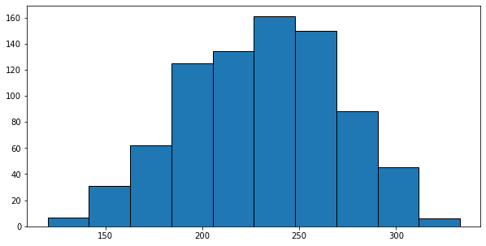

```python
np.random.seed(45)

mean_males = 204
std_males = 31

mean_females = 257
std_females = 28

sales_males = np.random.normal(mean_males, std_males, 387)
sales_females = np.random.normal(mean_females, std_females, 422)

sales_total = np.concatenate([sales_males, sales_females])

_ = plt.hist(sales_total, edgecolor='k', linewidth=1)
```

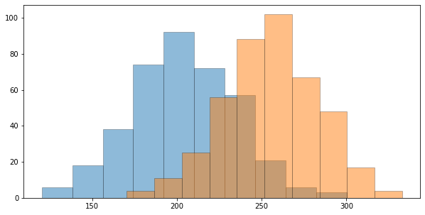

```python
_ = plt.hist(sales_males, alpha=0.5, edgecolor='k', linewidth=0.5)
_ = plt.hist(sales_females, alpha=0.5, edgecolor='k', linewidth=0.5)
```

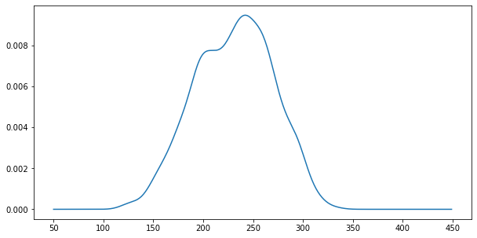

```python
kde_total = sp.stats.gaussian_kde(sales_total, bw_method=0.21)

x_axis = np.arange(50, 450)
y_axis_total = kde_total.evaluate(x_axis)
plt.plot(x_axis, y_axis_total)
```

### Finite Mixtures - Cont'd

- Here, the total sales is a finite mixture of two distributions
  - A mixture distribution is the probability distribution of a random variable that is derived from a collection of other random variables
- Mixtures occur naturally
  - When you study spending on the apple store, the distribution of prices for professional applications may be substantially different from other apps.
    - Ex. prices for apps for doctors, stock traders, frequent travelers, etc. may be substantially different than apps for general public
  - Measuring some phenotype in the population, ex. Height or weight, or blood sugar will undoubtedly contain multiple distributions.
  - etc.
- Some probabilistic models can account for an infinite number of components (clusters)
  - Used, for instance, in clustering species or documents.

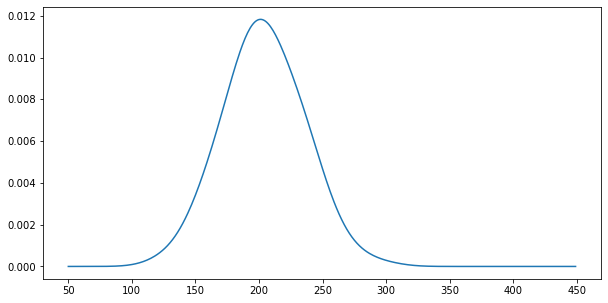

```python
kde_males = sp.stats.gaussian_kde(sales_males, bw_method=0.5)
y_axis_males = kde_males.evaluate(x_axis)
plt.plot(x_axis, y_axis_males)
```

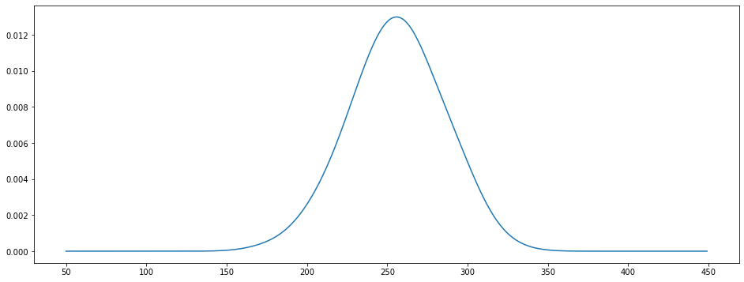

```python
plt.figure(figsize=(16,6))
kde_females = sp.stats.gaussian_kde(sales_females, bw_method=0.5)
y_axis_females = kde_females.evaluate(x_axis)
plt.plot(x_axis, y_axis_females)
```

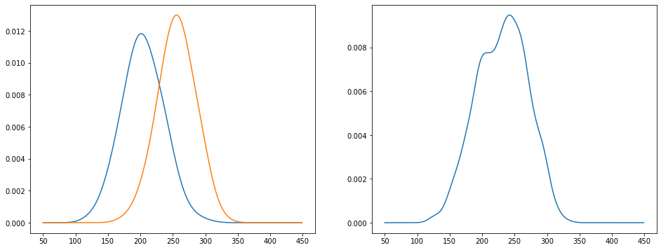

```python
plt.figure(figsize=(16,6))
plt.subplot(1,2,1)
plt.plot(x_axis, y_axis_males)
plt.plot(x_axis, y_axis_females)

plt.subplot(1,2,2)
kde_females.evaluate(x_axis)
plt.plot(x_axis, y_axis_total)
```

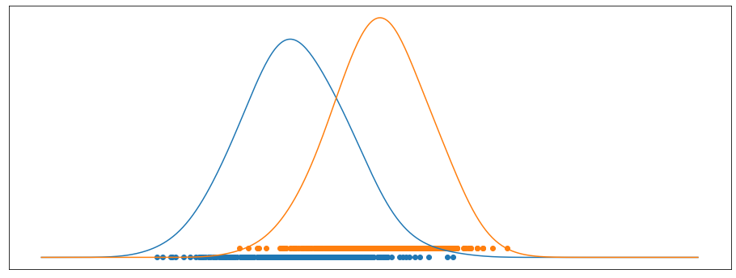

```python
plt.figure(figsize=(16,6))

plt.plot(x_axis, y_axis_males)
plt.plot(x_axis, y_axis_females)

plt.scatter(sales_males, np.zeros(len(sales_males)))
plt.scatter(sales_females, np.zeros(len(sales_females))+0.0005)

_ = plt.xticks([], [])
_ = plt.yticks([], [])
```

### Using k-means to identify the two cluster clusters

- We know the sales_total is a concatenation of `sales_males` and `sales_females`
  - Contains the sales info from 387 males and 422 females
- We can assign each entry in sales_total either male (0) or female (1)

```python
y_true = np.concatenate([np.zeros(387), np.ones(422)])

y_true[380:394]
```

```
array([0., 0., 0., 0., 0., 0., 0., 1., 1., 1., 1., 1., 1., 1.])
```

```python
from sklearn.cluster import KMeans
y_predicted = KMeans(n_clusters=2).fit_predict(sales_total.reshape(-1,1))
```

```python
y_predicted[0:40]
```

```
array([1, 1, 1, 1, 1, 1, 1, 1, 1, 0, 1, 1, 1, 0, 1, 1, 1, 1, 1, 1, 1, 1,
       1, 1, 1, 0, 1, 1, 0, 1, 1, 1, 1, 0, 1, 0, 1, 1, 1, 1], dtype=int32)
```

```python
y_predicted[-40:]
```

```
array([0, 0, 0, 1, 0, 1, 1, 0, 1, 0, 1, 0, 0, 0, 0, 0, 0, 0, 0, 0, 0, 0,
       0, 1, 0, 0, 0, 0, 0, 0, 0, 0, 1, 1, 0, 0, 0, 0, 0, 0], dtype=int32)
```

```python
y_predicted = 1- y_predicted
sum(y_predicted == y_true) / len(y_predicted)
```

```
0.8108776266996292
```

```python
pred_males = np.where(y_predicted == 0)
pred_females = np.where(y_predicted == 1)


pred_males_error = np.where((y_predicted == 0) & (y_true == 1))
pred_females_error = np.where((y_predicted == 1) & (y_true == 0))
```

```
([], [])
```

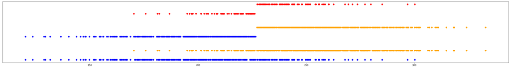

```python
plt.figure(figsize=(40,5))

# REAL DATA
plt.scatter(sales_total[:len(sales_males)], np.zeros(len(sales_males)), color='blue')
plt.scatter(sales_total[len(sales_males):], np.zeros(len(sales_females))+0.02, color='orange')


# PREDICTED DATA
plt.scatter(sales_total[pred_males], np.zeros(len(y_predicted[pred_males]))+0.05, color='blue')
plt.scatter(sales_total[pred_females], np.zeros(len(y_predicted[pred_females]))+0.07, color='orange')


# ERRORS IN PREDICTION
plt.scatter(sales_total[pred_males_error], np.zeros(len(y_predicted[pred_males_error]))+0.1, color='red')
plt.scatter(sales_total[pred_females_error], np.zeros(len(y_predicted[pred_females_error]))+0.12, color='red')

plt.yticks([], [])
```

### Impracticality of the K-means

- Works well on *blobs* of data
  - The boundary of each cluster is always circular, with the center of the cluster being the mean
- Does not work well overlapping clusters; including overlapping blobs
  - No confidence in the uncertainty in the assignment of each point.
- Here, we need an approach that let us include that uncertainty in the clustering

```python
import numpy as np
np.random.binomial(1, 0.7, 500)
```

[output not shown]

### Modeling a Mixture Distribution

- In the above, we assumed that we know the exact number of males and females
  - The number of males and females should also be a parameter to our model
    - Should sample gender from a binomial (ex. for 500 individuals and a proportion of males/females = 0.7)

      ```
      np.random(1, 0.7, 500)
      ```

- A more accurate generative model of the mixture distribution can be derived as follows

### Defining the Mixture dsitribution

[figure not shown]

```python
np.random.seed(42)
male_female_prop = 0.45

mean_males = 204
std_males = 31

mean_females = 257
std_females = 28

sales_males =  []
sales_females = []

cluster = []


for i in range(1000):
    gender = np.random.choice([0,1], p = [male_female_prop, 1- male_female_prop])
    if gender == 0:
        cluster.append(0)
        male_sale = np.random.normal(mean_males, std_males)
        sales_males.append(male_sale)
    else:
        cluster.append(1)
        female_sale = np.random.normal(mean_females, std_females)
        sales_females.append(female_sale)



sales_total = np.concatenate([sales_males, sales_females])
```

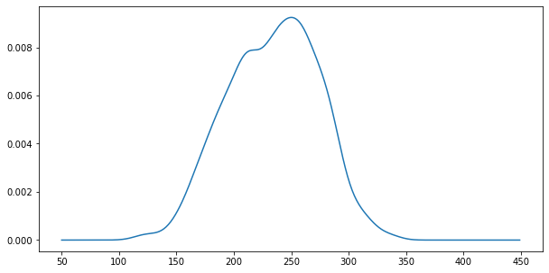

```python
kde_total = sp.stats.gaussian_kde(sales_total, bw_method=0.22)
x_axis_total = np.arange(50, 450)
y_axis_total_kde = kde_total.evaluate(x_axis_total)
plt.plot(x_axis, y_axis_total_kde)
```

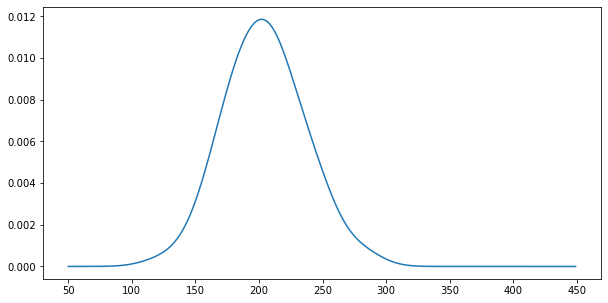

```python
kde_males = sp.stats.gaussian_kde(sales_males, bw_method=0.5)
x_axis_males = np.arange(50, 450)
y_axis_males_kde = kde_males.evaluate(x_axis_males)
plt.plot(x_axis_males, y_axis_males_kde)
```

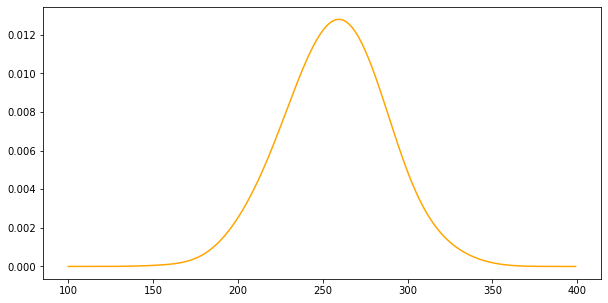

```python
kde_females = sp.stats.gaussian_kde(sales_females, bw_method=0.5)
x_axis_females = np.arange(100, 400)
y_axis_females_kde = kde_females.evaluate(x_axis_females)
plt.plot(x_axis_females, y_axis_females_kde, color="orange")
```

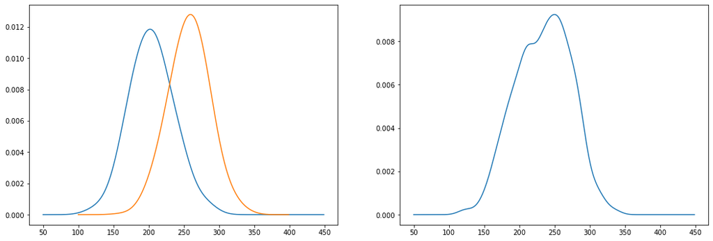

```python
plt.figure(figsize=(18,6))
plt.subplot(1, 2, 1)
plt.plot(x_axis_males, y_axis_males_kde)
plt.plot(x_axis_females, y_axis_females_kde)
plt.subplot(1, 2, 2)
plt.plot(x_axis, y_axis_total_kde)
```

### Decomposing the Mixture

- How do we construct a mixture distribution from other random variables?
- The mixture distribution is simply the sum of the two distribution
  - Each point $x$ is evaluated using $f_male(x)$ and $f_males$ where
    - $ X_{male} \sim \mathcal{N}(\mu_{male},\sigma_{male})$ and $X_{female} \sim \mathcal{N} (\mu_{female},\sigma_{female})$.
- Recall that:

- $\mu$ and $\sigma$ depend on the size of the sample
  - combining $X_{male}$ and $X_{female}$ requires us to normalize by the sample size

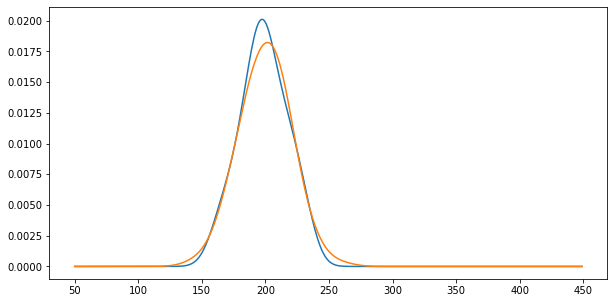

```python
mean_males_temp  = 200
std_males_temp = 20

male_sales_1 = np.random.normal(mean_males_temp, std_males_temp, 100)
male_sales_2 = np.random.normal(mean_males_temp, std_males_temp, 500)

kde_males_1 = sp.stats.gaussian_kde(male_sales_1, bw_method=0.5)
kde_males_2 = sp.stats.gaussian_kde(male_sales_2, bw_method=0.5)

x_axis_temp = np.arange(50, 450)
y_axis_males_kde_1 = kde_males_1.evaluate(x_axis_temp)
y_axis_males_kde_2 = kde_males_2.evaluate(x_axis_temp)

plt.plot(x_axis_temp, y_axis_males_kde_1)
plt.plot(x_axis_temp, y_axis_males_kde_2)
```

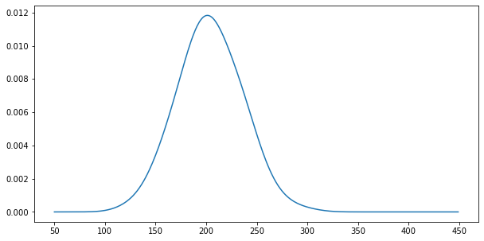

```python
mean_males = 204
std_males = 31

x_axis = np.arange(50, 450)
y_axis_males_theoretical = sp.stats.norm.pdf(x_axis, mean_males, std_males)
plt.plot(x_axis, y_axis_males)
```

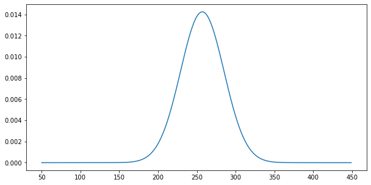

```python
mean_females = 257
std_females = 28

x_axis = np.arange(50, 450)
y_axis_females_theoretical = sp.stats.norm.pdf(x_axis, mean_females, std_females)

plt.plot(x_axis, y_axis_females_theoretical)
```

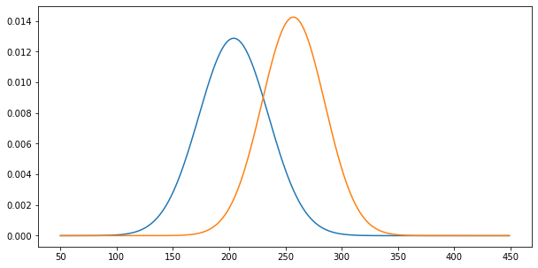

```python
plt.plot(x_axis, y_axis_males_theoretical)
plt.plot(x_axis, y_axis_females_theoretical)
```

```python
len(sales_males), len(sales_females)
```

```
(439, 561)
```

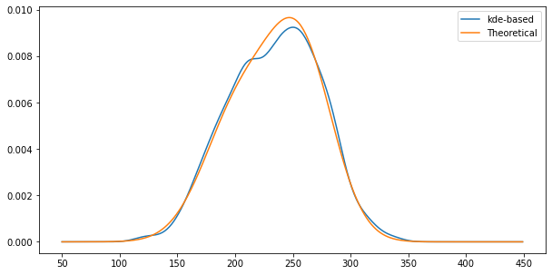

```python
y_axis_total_theoretical = ((len(sales_males) / 1000) * y_axis_males_theoretical
                                + (len(sales_females) / 1000) * y_axis_females_theoretical)

plt.plot(x_axis, y_axis_total_kde, label= "kde-based")
plt.plot(x_axis, y_axis_total_theoretical,  label= "Theoretical")
plt.legend()
```

### Question

- We have access to the two means ($\mu_1$ and $\mu_2$) and two std deviations ($\sigma_1$ and $\sigma_2$) describing two populations $P_1$ and $P_2$
- Given a new point, $x_1$, how can guess which population the point is most likely to have come from?

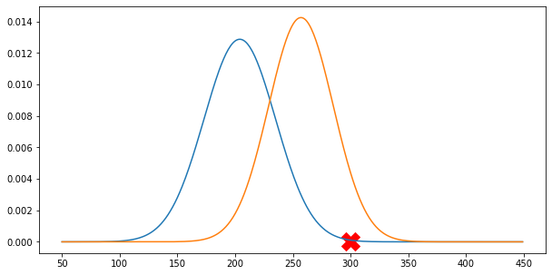

```python
plt.plot(x_axis, y_axis_males_theoretical)
plt.plot(x_axis, y_axis_females_theoretical)
plt.scatter(300, 0, color='red',marker="X", s=400)
```

### Inferring Model Parameters of Gaussian Mixture Model

- The paramter we need to infer here are:
  1. The mean and standard deviation for the males' sales
  2. The mean and standard deviation for the females' sales
  3. The proportion of males to females
- Catch 22
  - We can easily infer these parameters if we know which point comes from which group
    - compute the mean and std dev. for each group independently
  - if we know the means and std deviations, we could easily assign an unknown point to its distribution
    - compute the probability of each point under each distribution

### Key Idea 1

- if we know the which cluster each of the points belong to, then generating the model params is easy

[figure not shown]

### Key Idea 1 - Cont'd

- Computing the mean and standard deviation of each point

[figure not shown]

## Inferring the Likelhood of Each Point Under Each Cluster

- The Likelihood that a data point $x$ came from the blue curve is

$$ p(x| \mu_b, \sigma_b) = \frac{1}{\sqrt{2\pi\sigma_b^2}}exp(-\frac{(x-\mu_b)^2}{2\sigma_b^2}) $$

- The probability that the point came from the orange curve is

$$ p(x| \mu_o, \sigma_o) = \frac{1}{\sqrt{2\pi\sigma_o^2}}exp(-\frac{(x-\mu_o)^2}{2\sigma_o^2}) $$

```python
print(mean_males, std_males)
print(mean_females, std_females)
```

```
204 31
257 28
```

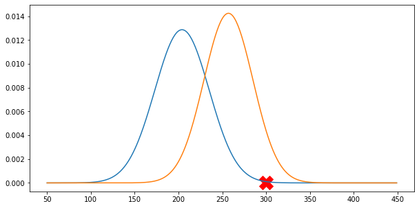

```python
pdf_males_curve = sp.stats.norm.pdf(300, mean_males, std_males)

pdf_females_curve = sp.stats.norm.pdf(300, mean_females, std_females)


plt.plot(x_axis, y_axis_males_theoretical)
plt.plot(x_axis, y_axis_females_theoretical)
plt.scatter(300, 0, color='red',marker="X", s=400)
```

```python
print("Probablity that the point come from the males distribution is {} ", pdf_males_curve / (pdf_males_curve + pdf_females_curve))
print("Probablity that the point come from the females distribution is {} ", pdf_females_curve / (pdf_males_curve + pdf_females_curve))
```

```
Probablity that the point come from the males distribution is {}  0.02371657625929116
Probablity that the point come from the females distribution is {}  0.9762834237407089
```

### Key Idea 2

- Each observation is assumed to belong to a cluster $c_i$ according to membership probabilities that sum up to 1
  - We do not use a “hard” label that assigns a point exclusively to either clusters
- Observation above has $X\%$ of belonging to the blue cluster and Y% belonging to the orange cluster
  - we compute these probabilities as: $$ X = \frac{{p(x \in \mbox{cl}_b~\mbox{|}~~ \mu_b, \sigma_b)}}{{\sum_{j}{p(x \in \mbox{cl}_b~\mbox{|}~~ \mu_b, \sigma_b) + p(x \in \mbox{cl}_o~\mbox{|}~~ \mu_o, \sigma_o)}}} $$

$$ Y = \frac{{p(x \in \mbox{cl}_o~\mbox{|}~~ \mu_o, \sigma_o)}}{{\sum_{j}{p(x \in \mbox{cl}_b~\mbox{|}~~ \mu_b, \sigma_b) + p(x \in \mbox{cl}_o~\mbox{|}~~ \mu_o, \sigma_o)}}} $$

### Using Expectation-Maximization

- Expectation-Maximization (EM) is a popular algorithm used to infer the hidden groupings in situations with interdependence
  - An iterative procedure that alternates between:
- Pretending that we know the params of each cluster (ex. $mu_i$ and $\sigma_i$)
- Pretending we know the probability with which each observation belongs to a component
- We iterate until we see no substantial improvement in our optimizations

### Using Expectation-Maximization - Cont'd

- Pretending that we know the params of each cluster
  - We use that information to estimate the probability that each point belongs to each component
  - We do not assign a point to a cluster as in K-Means
- Pretending we know the probability with which each observation belongs to a component
  - Use that information to estimate the distribution parameters of each cluster
  - Recall that a point does not belowng exclusively to one single cluster
    - This something we need to take into account.

### The E-M Algorithm in K-Means

- Although we did not expressively define it as so, K-Means also uses expectation–maximization
  - Choose starting guesses for the location
- For each point, repeat until converged:
  - E-step: for each point, find its closest mean and assign it to it
  - M-step: for each cluster, update clusters' means, based on all data points in each cluster

### E-M Example: The Data

- We are analyzing data in one dimension ($x$)
  - We know the data comes from two clusters but is unlabeled
  - We want to discover the params of those Gaussians

[figure not shown]

### E-M Example: The initialization

- We initialize the distributions parameters using random values for the means and the standard deviations
  - Means can be assigned randomly or using more informed methods, such using a full round of K-Means

[figure not shown]

### E-M Algorithm: Expectation Step

- How likely is each of the points to be from each of the distribution?
  - Given each point, what its `pdf` given each of the Gaussians?
  - Each point has a little bit of the first distribution and a bit of the second
    - Here we use colors (blue and orange) to illustrate that

[figure not shown]

### E-M Algorithm: Expectation Step

- A point $i$ is $O_i$ orange and $B_i$ blue, where

$$ B_i = \frac{p(x_i| \mu_b, \sigma_b)}{p(x_i| \mu_b, \sigma_b) + p(x_i| \mu_o, \sigma_o)}, $$

and

$$ O_i = \frac{p(x_i| \mu_o, \sigma_o)}{p(x_i| \mu_b, \sigma_b) + p(x_i| \mu_o, \sigma_o)}, $$

- Recompute the means and the std. deviations of each distribution based on its points
  - Each of the points is going to contribute only its probabilitues worth to computing the params ($B_i$ and $O_i$)

### E-M Algorithm: Maximization Step - Cont'd

- Ex. Rather use compute the mean as $\mu_b = \sum x_i/n_b$, we are going to use a weighted average

$$ \mu_b = \frac{\sum {B_i}x_i}{\sum B_i} $$$$ \sigma_b = \frac{\sum {B_i}(x_i - \mu_b)^2}{\sum B_i} $$

- We compute the variance in a similar fashion by discounting the contributions of each point by its contribution to other clusters
- It is easier to understand this if you think of it in terms of k-means (the $b_i$s are simply 0 or 1).
  - i.e., in k-means gives all its mass to one point
  - Here, each point gives some value in [0,1] to each of the Gaussians

### E-M Algorithm: Maximization Step

[figure not shown]

### E-M Algorithm: Second Iteration

[figure not shown]

### E-M Algorithm: Final Results

- After multiple iteration, we arrive at a stable solution

[figure not shown]

### Assumptions about EM

- Note that here, we assumed that priors for each cluster are identical, i.e. $P(O) =P(B)$
- If that's not the case, then we would need to evaluate the priors for each iteration
- $P(B) = \sum(B_i) / n$
  - it's common to start with equal priors to avoid the possibility that a cluster is squashed
  - if P(O)=0, then our solution never works
- Similar to k-means, there are no guarantees that EM converges
  - Common to repeat using different initializations

### Gaussian Mixture Model

- A data modeling technique which attempts to find a mixture of Gaussian probability distributions that best model the input
- Assumes the source is Gaussian
  - The Gaussian can be multi-dimensional
- Instead of assigning a point to a cluster assigns the point to the all clusters $c_i$, each with a probability $p_i$
  - Provides confidence measure about the point being in any of the clusters
- Uses the EM to identify the param of each component

```python
X1 = np.random.multivariate_normal([0, 0], [[3,0], [0,10]], 100)
X2 = np.random.multivariate_normal([5, 5], [[4,0], [0,10]], 100)
y_true = [0]*len(X1) + [1]*len(X2)
X= np.concatenate([X1, X2])
X.shape
```

```
(200, 2)
```

```python
X[:4, :]
```

```
array([[-0.47052045, -1.72875422],
       [ 2.32174665,  5.29192016],
       [ 1.4371387 , -4.10963671],
       [-1.98885036,  2.5658612 ]])
```

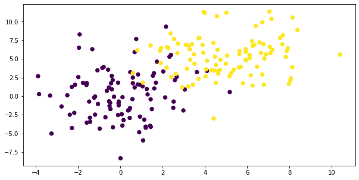

```python
plt.scatter(X[:,0], X[:,1], c=y_true , s=40, cmap='viridis')
```

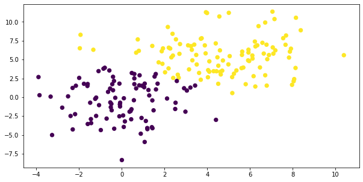

```python
from sklearn.cluster import KMeans
kmeans = KMeans(2, random_state=0)
labels = kmeans.fit_predict(X)

plt.scatter(X[:, 0], X[:, 1], c=1-labels, s=40, cmap='viridis');
```

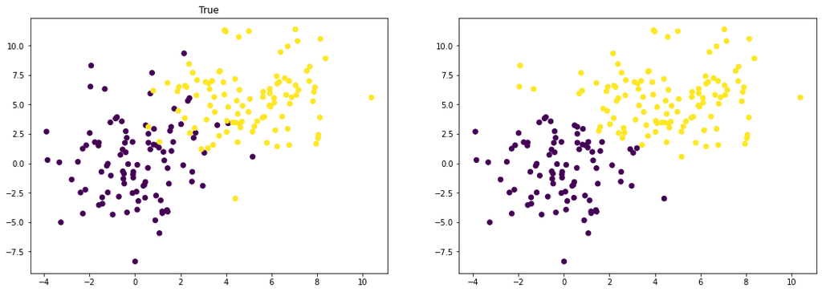

```python
plt.figure(figsize=(18,6))

plt.subplot(1,2,1)
plt.scatter(X[:, 0], X[:, 1], c=y_true, s=40, cmap='viridis');
plt.title("True")


from sklearn.mixture import GaussianMixture
gmm = GaussianMixture(n_components=2, covariance_type="spherical", max_iter=1000).fit(X)
labels = gmm.predict(X)
plt.subplot(1,2,2)
plt.scatter(X[:, 0], X[:, 1], c=1-labels, s=40, cmap='viridis');
```

```python
data = pd.DataFrame({"y_true": y_true, "predicted": 1- labels})
data[data["y_true"] != data["predicted"]]
```

|  | y_true | predicted |
| --- | --- | --- |
| 5 | 0 | 1 |
| 6 | 0 | 1 |
| 15 | 0 | 1 |
| 17 | 0 | 1 |
| 18 | 0 | 1 |
| 28 | 0 | 1 |
| 46 | 0 | 1 |
| 56 | 0 | 1 |
| 63 | 0 | 1 |
| 66 | 0 | 1 |
| 74 | 0 | 1 |
| 94 | 0 | 1 |
| 105 | 1 | 0 |
| 107 | 1 | 0 |
| 111 | 1 | 0 |
| 114 | 1 | 0 |
| 124 | 1 | 0 |
| 140 | 1 | 0 |
| 143 | 1 | 0 |
| 175 | 1 | 0 |
| 176 | 1 | 0 |
| 181 | 1 | 0 |
| 187 | 1 | 0 |
| 196 | 1 | 0 |

```python
data["prob"] = predictions
data.head()
```

[output not shown]

|  | y_true | predicted | prob |
| --- | --- | --- | --- |
| 0 | 0 | 0 | 0.970 |
| 1 | 0 | 0 | 0.996 |
| 2 | 0 | 0 | 0.988 |
| 3 | 0 | 0 | 0.817 |
| 4 | 0 | 0 | 0.987 |

```python
data[data["y_true"] != data["predicted"]]
```

[output not shown]

[figure not shown]

```python
good = np.where(data["prob"] > 0.85)

plt.figure(figsize=(18,6))

plt.subplot(1,2,1)
plt.scatter(X[:, 0], X[:, 1], c=y_true, s=40, cmap='viridis');


plt.subplot(1,2,2)
plt.scatter(X[:, 0], X[:, 1], c=1-labels, s=50**data["prob"], cmap='viridis');
```

### Multivariate Gaussians

```python
male_weights = np.random.normal(87, 13, 100)
female_weights = np.random.normal(73, 8, 100)

male_heights = np.random.normal(87, 13, 100)
female_heights = np.random.normal(73, 8, 100)
```

```
([], [])
```

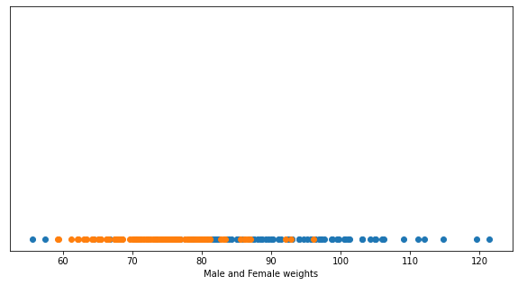

```python
plt.scatter(male_weights,np.zeros(len(male_weights)))
plt.scatter(female_weights,np.zeros(len(female_weights)))
plt.ylim(-0.05,1)
plt.xlabel("Male and Female weights")
plt.yticks([], [])
```

```
([], [])
```

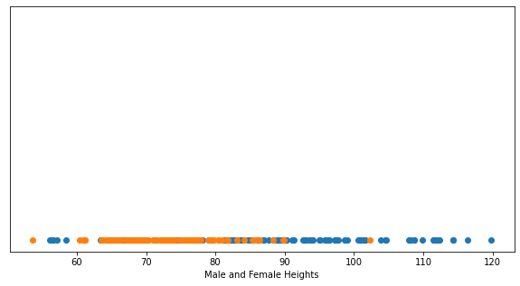

```python
plt.scatter(male_heights,np.zeros(len(male_heights)))
plt.scatter(female_heights,np.zeros(len(female_heights)))
plt.xlabel("Male and Female Heights")
plt.ylim(-0.05,1)
plt.yticks([], [])
```

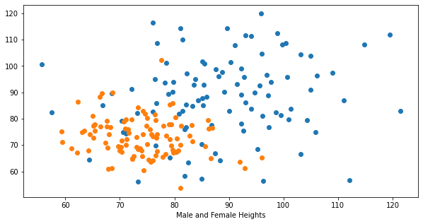

```python
plt.scatter(male_weights, male_heights)
plt.scatter(female_weights,female_heights)
plt.xlabel("Male and Female Weights")
plt.xlabel("Male and Female Heights")
```

### Multivariate Gaussian

- A multivariate Gaussian distribution, or joint Guassian distribution is a generalization of the one-dimensional (univariate) normal distribution to higher dimensions.
  - Bivariate is the generalization of two joint Gaussian distributions
- A random random vector is said to be k-variate normally distributed if every linear combination of its k components has a univariate normal distribution.

### Multivariate Gaussian - Cont'd

- The multivariate normal distribution of a k-dimensional random vector $ \mathbf {X} =(X_{1},\ldots ,X_{k}) $, where

$ X_i \ \sim \ {\mathcal {N}}({\mu_i},\, \sigma_i)$.

and $ \mathbf {X} \ \sim \ {\mathcal {N}}({\boldsymbol {\mu }},\,{\boldsymbol {\Sigma }})$, where $\Sigma$ is the covariance matrix, i.e.,

$ \Sigma _{i,j} = \operatorname {Cov} [X_{i},X_{j}] $

- Recall that you can think of the covariance as a "sort of" scale free measure of the dependence between two variables $X_i$ and $X_j$
  - Unlike correaltion, covariance, change in scale affects the covariance, which ranges between $-\infty$ and $+\infty$

$$ cov(X_i, X_j) = corr(X_i, X_j) \times \sigma_{X_i}\sigma_{X_j} $$

### The Covariance Matrix

[figure not shown]

- $ \Sigma _{i,j} = \operatorname {Cov} [X_{i},X_{j}] $
  - $ \Sigma _{i,i} = \operatorname {Cov} [X_{i},X_{j}]$
    - That's simply the $var(X_i)$

```python
### The Covariance Matrix

cov_matrix  = [[0.5, 0], [0, 0.5]]
data =  np.random.multivariate_normal([20, 40], cov_matrix, 10)
data
```

```
array([[20.49412012, 41.14150761],
       [19.4640643 , 40.0165449 ],
       [19.70722784, 39.85439253],
       [19.20713876, 40.12813574],
       [20.22090699, 39.71240168],
       [20.00050928, 40.58741923],
       [18.96378392, 40.89442228],
       [19.45433462, 39.78557735],
       [20.07328063, 40.65947278],
       [20.82529649, 40.46883894]])
```

```
(36.0, 44.0)
```

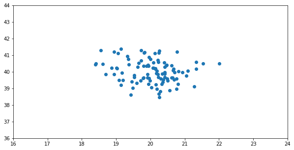

```python
data =  np.random.multivariate_normal([20, 40], cov_matrix, 100)

plt.scatter(data[:,0], data[:,1])
plt.xlim(16, 24)
plt.ylim(36, 44)
```

```
(25.0, 55.0)
```

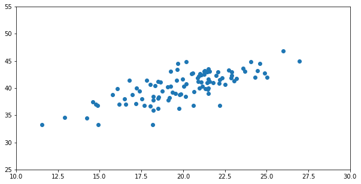

```python
cov_matrix  = [[6.6, 5.35], [5.35, 6.9]]
data =  np.random.multivariate_normal([20, 40], cov_matrix, 100)


plt.scatter(data[:,0], data[:,1])
plt.xlim(10, 30)
plt.ylim(25, 55)
```

```
(25.0, 55.0)
```

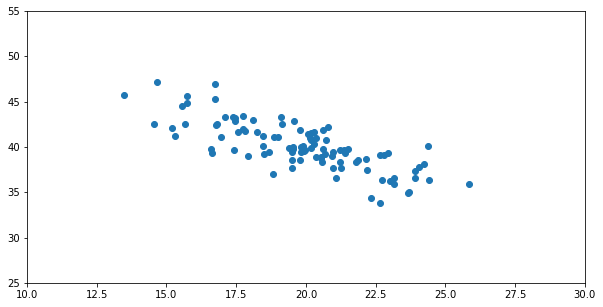

```python
cov_matrix  = [[6.6, -5.35], [-5.35, 6.9]]
data =  np.random.multivariate_normal([20, 40], cov_matrix, 100)


plt.scatter(data[:,0], data[:,1])
plt.xlim(10, 30)
plt.ylim(25, 55)
```

### Bivariate Gaussian

- We are going to model all the data in one go
- The params of a a mutivariate gaussian are the vector of means $M \in \mathcal{R}^{d} $ and the covariance matrix $\Sigma \in \mathcal{R}^{d \times d}$

[figure not shown]

### How to Determine the Number of Gaussians to Represent the Data?

- Similar Problem to finding the number of means in k-means
  - Use, for instance, Silhouette Index
- Also, the probabilistic Nature makes it easier to define an objective function
  - This is just the function we want to optimize
  - We can just compute the value of clusters that maximizes the likelihood